# Annual Fund $10K Model Data Exploration

### Numeric variables

Uses $\log_{10}$ transformation for dollars and $\sqrt{\ \ }$ transformation for counts.

```r
summary2(full.data$FIRST_KSM_YEAR)
```

```
     Min.   1st Qu.    Median      Mean   3rd Qu.      Max.     StDev Skewnewss  Kurtosis
     0.00   1950.00   1990.00   1710.00   2000.00   2020.00    688.00     -2.07      2.31
```

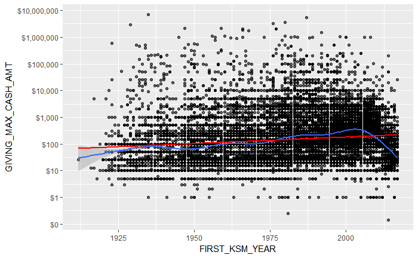

```r
scatterplotter('FIRST_KSM_YEAR', full.data %>% filter(FIRST_KSM_YEAR > 0))
```

Appears approximately linear until people graduating ~10 years ago.

```r
summary2(full.data$GIVING_FIRST_YEAR)
```

```
     Min.   1st Qu.    Median      Mean   3rd Qu.      Max.     StDev Skewnewss  Kurtosis
   0.0000    0.0000 1980.0000 1020.0000 2000.0000 2020.0000  998.0000   -0.0518   -2.0000
```

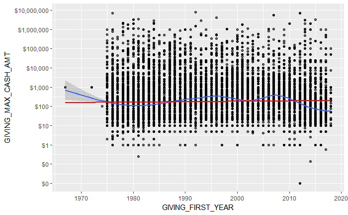

```r
scatterplotter('GIVING_FIRST_YEAR')
```

Same as previous.

```r
summary2(full.data %>% select(GIVING_FIRST_YEAR_CASH_AMT) %>%
  filter(GIVING_FIRST_YEAR_CASH_AMT > 0) %>% unlist() %>% log10())
```

```
     Min.   1st Qu.    Median      Mean   3rd Qu.      Max.     StDev Skewnewss  Kurtosis
   -2.000     1.400     1.700     1.850     2.180     7.200     0.676     1.040     2.870
```

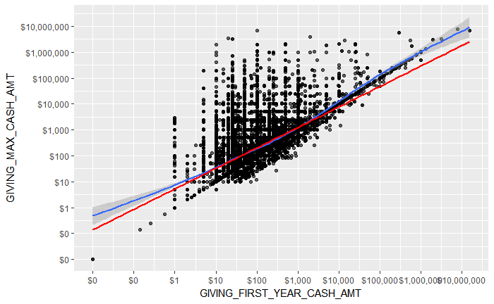

```r
scatterplotter('GIVING_FIRST_YEAR_CASH_AMT'
               , full.data %>% filter(GIVING_FIRST_YEAR_CASH_AMT > 0)) +
  scale_x_log10(breaks = 10^(-2:7), labels = scales::dollar)
```

Nearly an $x = y$ dividing line; not expected to be exact given that `GIVING_MAX_CASH_AMT` is single gifts. **CAUTION - endogenous**

```r
summary2(full.data %>% select(GIVING_FIRST_YEAR_PLEDGE_AMT) %>%
  filter(GIVING_FIRST_YEAR_PLEDGE_AMT > 0) %>% unlist() %>% log10())
```

```
     Min.   1st Qu.    Median      Mean   3rd Qu.      Max.     StDev Skewnewss  Kurtosis
    0.000     2.100     2.480     2.490     2.880     6.780     0.602     0.520     3.860
```

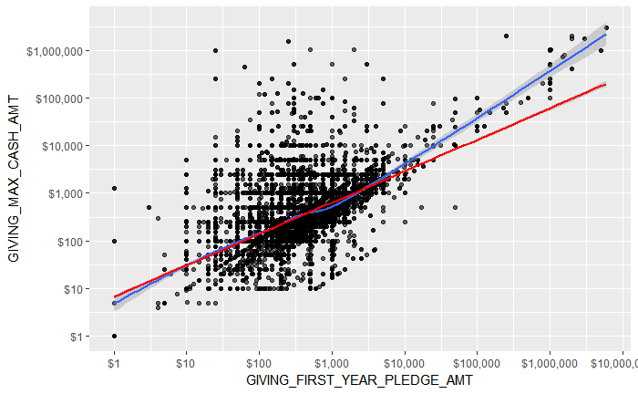

```r
scatterplotter('GIVING_FIRST_YEAR_PLEDGE_AMT'
               , full.data %>% filter(GIVING_FIRST_YEAR_PLEDGE_AMT > 0)) +
  scale_x_log10(breaks = 10^(-2:7), labels = scales::dollar)
```

Looks ok, but probably need a cutoff. **CAUTION - endogenous**

```r
summary2(full.data %>% select(GIVING_CASH_TOTAL) %>%
  filter(GIVING_CASH_TOTAL > 0) %>% unlist() %>% log10())
```

```
     Min.   1st Qu.    Median      Mean   3rd Qu.      Max.     StDev Skewnewss  Kurtosis
   -2.000     2.000     2.650     2.650     3.210     7.230     0.920     0.446     0.607
```

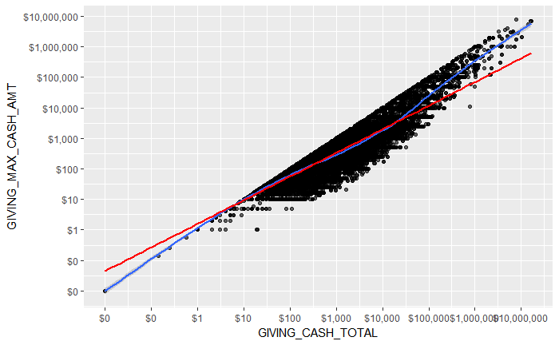

```r
scatterplotter('GIVING_CASH_TOTAL'
               , full.data %>% filter(GIVING_CASH_TOTAL > 0)) +
  scale_x_log10(breaks = 10^(-2:7), labels = scales::dollar)
```

Linear trend bounded by $y = x$ as expected. **EXCLUDE**

```r
summary2(full.data %>% select(GIVING_PLEDGE_TOTAL) %>%
  filter(GIVING_PLEDGE_TOTAL > 0) %>% unlist() %>% log10())
```

```
     Min.   1st Qu.    Median      Mean   3rd Qu.      Max.     StDev Skewnewss  Kurtosis
    0.000     2.000     2.480     2.580     3.000     7.180     0.812     1.410     4.390
```

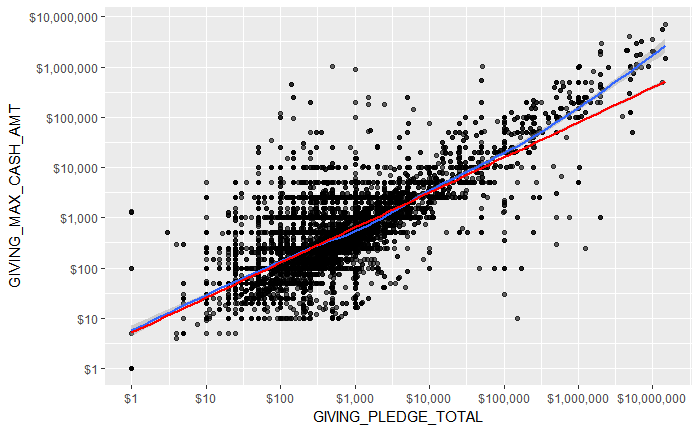

```r
scatterplotter('GIVING_PLEDGE_TOTAL'
               , full.data %>% filter(GIVING_PLEDGE_TOTAL > 0)) +
  scale_x_log10(breaks = 10^(-2:7), labels = scales::dollar)
```

Appears linear or piecewise linear, which follows given pledge payments. **EXCLUDE**

```r
summary2(full.data %>% select(GIVING_NGC_TOTAL) %>%
  filter(GIVING_NGC_TOTAL > 0) %>% unlist() %>% log10())
```

```
     Min.   1st Qu.    Median      Mean   3rd Qu.      Max.     StDev Skewnewss  Kurtosis
   -2.000     2.000     2.650     2.660     3.220     7.230     0.930     0.498     0.791
```

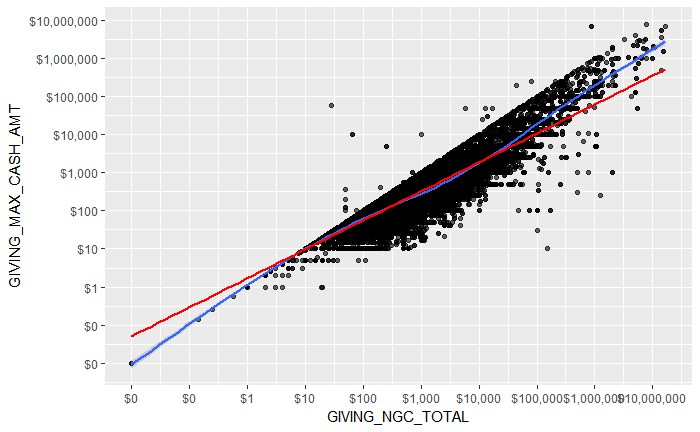

```r
scatterplotter('GIVING_NGC_TOTAL'
               , full.data %>% filter(GIVING_NGC_TOTAL > 0)) +
  scale_x_log10(breaks = 10^(-2:7), labels = scales::dollar)
```

Same as previous. **EXCLUDE**

```r
summary2(full.data$GIFTS_ALLOCS_SUPPORTED %>% sqrt())
```

```
     Min.   1st Qu.    Median      Mean   3rd Qu.      Max.     StDev Skewnewss  Kurtosis
    0.000     0.000     1.000     0.642     1.000     4.240     0.676     0.475    -0.853
```

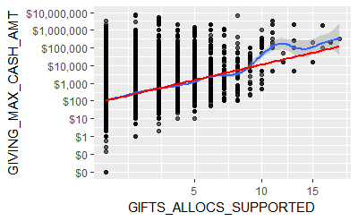

```r
scatterplotter('GIFTS_ALLOCS_SUPPORTED') +
  scale_x_sqrt()
```

Looks ok.

```r
summary2(full.data$GIFTS_FYS_SUPPORTED %>% sqrt())
```

```
     Min.   1st Qu.    Median      Mean   3rd Qu.      Max.     StDev Skewnewss  Kurtosis
     0.00      0.00      1.00      1.08      1.73      6.56      1.34      1.27      1.13
```

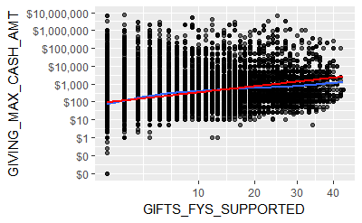

```r
scatterplotter('GIFTS_FYS_SUPPORTED') +
  scale_x_sqrt()
```

Looks ok.

```r
summary2(full.data$GIFTS_CASH %>% sqrt())
```

```
     Min.   1st Qu.    Median      Mean   3rd Qu.      Max.     StDev Skewnewss  Kurtosis
    0.000     0.000     0.000     0.788     1.410    17.500     1.260     1.860     3.550
```

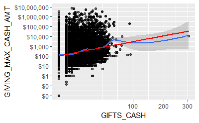

```r
scatterplotter('GIFTS_CASH') +
  scale_x_sqrt()
```

Would want to exclude the influential point around $x = 300$ if this is used. **Consider additional transformation**

```r
summary2(full.data$GIFTS_CREDIT_CARD %>% sqrt())
```

```
     Min.   1st Qu.    Median      Mean   3rd Qu.      Max.     StDev Skewnewss  Kurtosis
    0.000     0.000     0.000     0.437     1.000     8.120     0.848     2.260     5.780
```

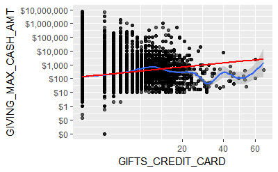

```r
scatterplotter('GIFTS_CREDIT_CARD') +
  scale_x_sqrt()
```

Looks ok; candidate for discretizing. **Consider additional transformation**

```r
summary2(full.data$GIFTS_STOCK %>% sqrt())
```

```
     Min.   1st Qu.    Median      Mean   3rd Qu.      Max.     StDev Skewnewss  Kurtosis
   0.0000    0.0000    0.0000    0.0207    0.0000    6.6300    0.2060   12.6000  194.0000
```

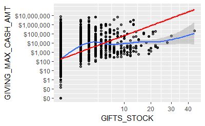

```r
scatterplotter('GIFTS_STOCK') +
  scale_x_sqrt()
```

Completely different 0 and 1+ slopes. Could be a candidate for binary indicator. **Consider additional transformation**

```r
rbind(
    summary2(full.data %>% select(CASH_PFY1) %>% filter(CASH_PFY1 > 0) %>% unlist() %>% log10())
  , summary2(full.data %>% select(CASH_PFY2) %>% filter(CASH_PFY2 > 0) %>% unlist() %>% log10())
  , summary2(full.data %>% select(CASH_PFY3) %>% filter(CASH_PFY3 > 0) %>% unlist() %>% log10())
  , summary2(full.data %>% select(CASH_PFY4) %>% filter(CASH_PFY4 > 0) %>% unlist() %>% log10())
  , summary2(full.data %>% select(CASH_PFY5) %>% filter(CASH_PFY5 > 0) %>% unlist() %>% log10())
)
```

```
       Min. 1st Qu. Median Mean 3rd Qu. Max. StDev Skewnewss Kurtosis
[1,] -0.252       2   2.40 2.49     3.0 6.32 0.826     0.880     1.50
[2,]  0.000       2   2.40 2.46     3.0 6.30 0.797     0.706     1.02
[3,]  0.000       2   2.40 2.45     3.0 6.92 0.806     0.620     1.60
[4,] -0.854       2   2.40 2.44     3.0 6.48 0.783     0.846     1.76
[5,]  0.000       2   2.33 2.39     2.7 6.61 0.717     0.887     2.19
```

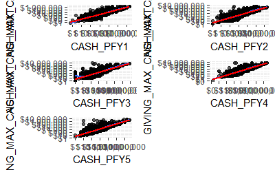

```r
# Grid plot
grid.arrange(
    scatterplotter('CASH_PFY1', full.data %>% filter(CASH_PFY1 > 0)) +
      scale_x_log10(breaks = 10^(-2:7), labels = scales::dollar)
  , scatterplotter('CASH_PFY2', full.data %>% filter(CASH_PFY2 > 0)) +
      scale_x_log10(breaks = 10^(-2:7), labels = scales::dollar)
  , scatterplotter('CASH_PFY3', full.data %>% filter(CASH_PFY3 > 0)) +
      scale_x_log10(breaks = 10^(-2:7), labels = scales::dollar)
  , scatterplotter('CASH_PFY4', full.data %>% filter(CASH_PFY4 > 0)) +
      scale_x_log10(breaks = 10^(-2:7), labels = scales::dollar)
  , scatterplotter('CASH_PFY5', full.data %>% filter(CASH_PFY5 > 0)) +
      scale_x_log10(breaks = 10^(-2:7), labels = scales::dollar)
)
```

High year-to-year correlations as expected. **CAUTION - endogenous**

```r
rbind(
    summary2(full.data %>% select(NGC_PFY1) %>% filter(NGC_PFY1 > 0) %>% unlist() %>% log10())
  , summary2(full.data %>% select(NGC_PFY2) %>% filter(NGC_PFY2 > 0) %>% unlist() %>% log10())
  , summary2(full.data %>% select(NGC_PFY3) %>% filter(NGC_PFY3 > 0) %>% unlist() %>% log10())
  , summary2(full.data %>% select(NGC_PFY4) %>% filter(NGC_PFY4 > 0) %>% unlist() %>% log10())
  , summary2(full.data %>% select(NGC_PFY5) %>% filter(NGC_PFY5 > 0) %>% unlist() %>% log10())
)
```

```
       Min. 1st Qu. Median Mean 3rd Qu. Max. StDev Skewnewss Kurtosis
[1,] -0.252       2    2.4 2.48     3.0 7.18 0.839     1.010     2.28
[2,] -1.400       2    2.4 2.46     3.0 7.06 0.788     0.643     1.34
[3,]  0.000       2    2.4 2.45     3.0 7.13 0.769     0.420     1.35
[4,] -0.854       2    2.4 2.44     3.0 7.00 0.789     0.930     2.21
[5,]  0.000       2    2.3 2.37     2.7 6.78 0.726     1.070     3.07
```

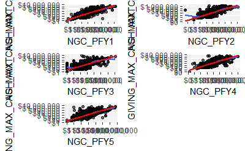

```r
# Grid plot
grid.arrange(
    scatterplotter('NGC_PFY1', full.data %>% filter(NGC_PFY1 > 0)) +
      scale_x_log10(breaks = 10^(-2:7), labels = scales::dollar)
  , scatterplotter('NGC_PFY2', full.data %>% filter(NGC_PFY2 > 0)) +
      scale_x_log10(breaks = 10^(-2:7), labels = scales::dollar)
  , scatterplotter('NGC_PFY3', full.data %>% filter(NGC_PFY3 > 0)) +
      scale_x_log10(breaks = 10^(-2:7), labels = scales::dollar)
  , scatterplotter('NGC_PFY4', full.data %>% filter(NGC_PFY4 > 0)) +
      scale_x_log10(breaks = 10^(-2:7), labels = scales::dollar)
  , scatterplotter('NGC_PFY5', full.data %>% filter(NGC_PFY5 > 0)) +
      scale_x_log10(breaks = 10^(-2:7), labels = scales::dollar)
)
```

Same as above. **CAUTION - endogenous**

```r
summary2(full.data$GIFT_CLUB_KLC_YRS %>% sqrt())
```

```
     Min.   1st Qu.    Median      Mean   3rd Qu.      Max.     StDev Skewnewss  Kurtosis
    0.000     0.000     0.000     0.109     0.000     3.320     0.446     4.490    20.700
```

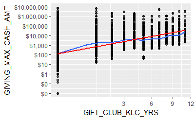

```r
scatterplotter('GIFT_CLUB_KLC_YRS') +
  scale_x_sqrt()
```

Surprisingly close to linear; looks ok.

```r
summary2(full.data$GIFT_CLUB_BEQUEST_YRS %>% sqrt())
```

```
     Min.   1st Qu.    Median      Mean   3rd Qu.      Max.     StDev Skewnewss  Kurtosis
 0.00e+00  0.00e+00  0.00e+00  9.17e-03  0.00e+00  1.41e+00  9.54e-02  1.03e+01  1.04e+02
```

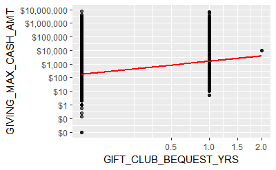

```r
scatterplotter('GIFT_CLUB_BEQUEST_YRS') +
  scale_x_sqrt()
```

Only 1 point with 2, so good candidate for binary indicator. **Consider additional transformation**

```r
summary2(full.data$GIFT_CLUB_LOYAL_YRS %>% sqrt())
```

```
     Min.   1st Qu.    Median      Mean   3rd Qu.      Max.     StDev Skewnewss  Kurtosis
    0.000     0.000     0.000     0.241     0.000     2.450     0.619     2.450     4.680
```

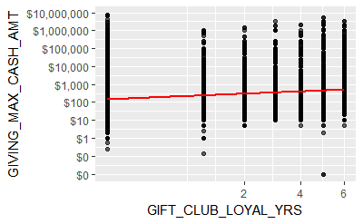

```r
scatterplotter('GIFT_CLUB_LOYAL_YRS') +
  scale_x_sqrt()
```

Looks ok but check how many are at each level. **Consider additional transformation**

```r
summary2(full.data$GIFT_CLUB_NU_LDR_YRS %>% sqrt())
```

```
     Min.   1st Qu.    Median      Mean   3rd Qu.      Max.     StDev Skewnewss  Kurtosis
    0.000     0.000     0.000     0.217     0.000     4.000     0.668     3.340    10.900
```

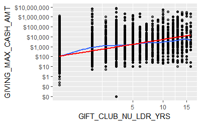

```r
scatterplotter('GIFT_CLUB_NU_LDR_YRS') +
  scale_x_sqrt()
```

Looks ok but check how many are at each level. **Consider additional transformation**

```r
rbind(
    summary2(full.data$VISITS_PFY1 %>% sqrt())
  , summary2(full.data$VISITS_PFY2 %>% sqrt())
  , summary2(full.data$VISITS_PFY3 %>% sqrt())
  , summary2(full.data$VISITS_PFY4 %>% sqrt())
  , summary2(full.data$VISITS_PFY5 %>% sqrt())
)
```

```
     Min. 1st Qu. Median   Mean 3rd Qu. Max. StDev Skewnewss Kurtosis
[1,]    0       0      0 0.0240       0 3.61 0.173      8.06     74.5
[2,]    0       0      0 0.0243       0 3.16 0.174      7.82     67.5
[3,]    0       0      0 0.0232       0 3.46 0.168      7.97     71.7
[4,]    0       0      0 0.0245       0 3.32 0.172      7.61     63.8
[5,]    0       0      0 0.0232       0 3.32 0.168      7.87     68.9
```

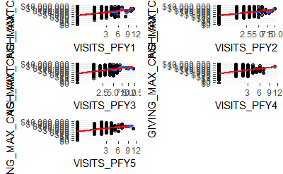

```r
# Grid plot
grid.arrange(
    scatterplotter('VISITS_PFY1') + scale_x_sqrt()
  , scatterplotter('VISITS_PFY2') + scale_x_sqrt()
  , scatterplotter('VISITS_PFY3') + scale_x_sqrt()
  , scatterplotter('VISITS_PFY4') + scale_x_sqrt()
  , scatterplotter('VISITS_PFY5') + scale_x_sqrt()
)
```

Hard to see what’s going on past 6 visits; seems to be about linear until then in each case. Try combining 5 years of visit counts.

```r
full.data <- full.data %>% mutate(
  VISITS = VISITS_PFY1 + VISITS_PFY2 + VISITS_PFY3 + VISITS_PFY4 + VISITS_PFY5
)
summary2(full.data$VISITS)
```

```
     Min.   1st Qu.    Median      Mean   3rd Qu.      Max.     StDev Skewnewss  Kurtosis
    0.000     0.000     0.000     0.149     0.000    40.000     0.978    15.100   352.000
```

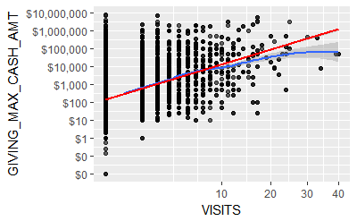

```r
scatterplotter('VISITS') + scale_x_sqrt()
```

More of a logarithmic relationship. **Consider log transformation**

```r
rbind(
    summary2(full.data$VISITORS_PFY1 %>% sqrt())
  , summary2(full.data$VISITORS_PFY2 %>% sqrt())
  , summary2(full.data$VISITORS_PFY3 %>% sqrt())
  , summary2(full.data$VISITORS_PFY4 %>% sqrt())
  , summary2(full.data$VISITORS_PFY5 %>% sqrt())
)
```

```
     Min. 1st Qu. Median   Mean 3rd Qu. Max. StDev Skewnewss Kurtosis
[1,]    0       0      0 0.0226       0 2.83 0.161      7.47     59.5
[2,]    0       0      0 0.0229       0 2.83 0.162      7.43     58.5
[3,]    0       0      0 0.0221       0 2.65 0.157      7.45     58.6
[4,]    0       0      0 0.0229       0 2.65 0.158      7.16     53.7
[5,]    0       0      0 0.0219       0 2.24 0.155      7.32     55.3
```

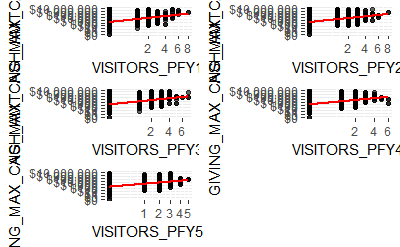

```r
# Grid plot
grid.arrange(
    scatterplotter('VISITORS_PFY1') + scale_x_sqrt()
  , scatterplotter('VISITORS_PFY2') + scale_x_sqrt()
  , scatterplotter('VISITORS_PFY3') + scale_x_sqrt()
  , scatterplotter('VISITORS_PFY4') + scale_x_sqrt()
  , scatterplotter('VISITORS_PFY5') + scale_x_sqrt()
)
```

Try combining 5 years of visitor counts.

```r
full.data <- full.data %>% mutate(
  VISITORS = VISITORS_PFY1 + VISITORS_PFY2 + VISITORS_PFY3 + VISITORS_PFY4 + VISITORS_PFY5
)
summary2(full.data$VISITORS)
```

```
     Min.   1st Qu.    Median      Mean   3rd Qu.      Max.     StDev Skewnewss  Kurtosis
    0.000     0.000     0.000     0.128     0.000    25.000     0.753    12.400   238.000
```

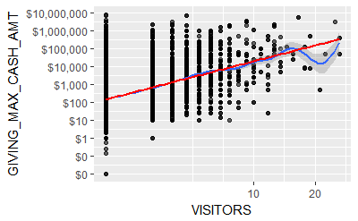

```r
scatterplotter('VISITORS') + scale_x_sqrt()
```

Looks ok.

```r
summary2(full.data$COMMITTEE_NU_DISTINCT %>% sqrt())
```

```
     Min.   1st Qu.    Median      Mean   3rd Qu.      Max.     StDev Skewnewss  Kurtosis
    0.000     0.000     0.000     0.586     1.000     5.920     0.763     1.070     0.693
```

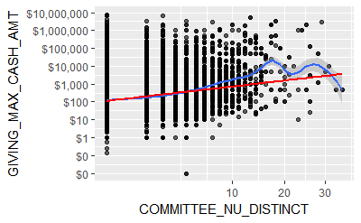

```r
scatterplotter('COMMITTEE_NU_DISTINCT') +
  scale_x_sqrt()
```

Looks like it might be piecewise-linear; consider discretizing. **Consider additional transformation**

```r
summary2(full.data$COMMITTEE_NU_ACTIVE %>% sqrt())
```

```
     Min.   1st Qu.    Median      Mean   3rd Qu.      Max.     StDev Skewnewss  Kurtosis
    0.000     0.000     0.000     0.295     0.000     4.800     0.541     1.620     1.780
```

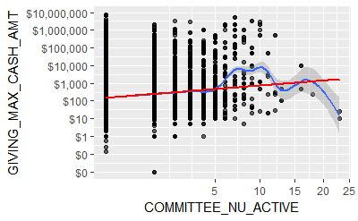

```r
scatterplotter('COMMITTEE_NU_ACTIVE') +
  scale_x_sqrt()
```

Likely unhelpful since I don’t know committees the year largest gift was made. **EXCLUDE**

```r
summary2(full.data$COMMITTEE_NU_YEARS %>% sqrt())
```

```
     Min.   1st Qu.    Median      Mean   3rd Qu.      Max.     StDev Skewnewss  Kurtosis
    0.000     0.000     0.000     0.530     1.000     4.800     0.774     1.260     0.824
```

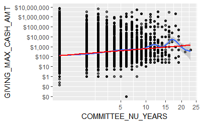

```r
scatterplotter('COMMITTEE_NU_YEARS') +
  scale_x_sqrt()
```

Looks fine.

```r
summary2(full.data$COMMITTEE_KSM_DISTINCT %>% sqrt())
```

```
     Min.   1st Qu.    Median      Mean   3rd Qu.      Max.     StDev Skewnewss  Kurtosis
    0.000     0.000     0.000     0.445     1.000     4.800     0.657     1.160     0.330
```

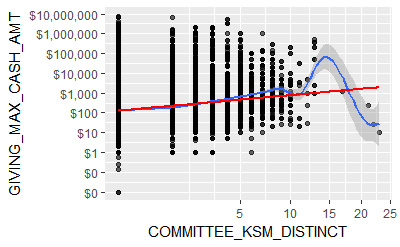

```r
scatterplotter('COMMITTEE_KSM_DISTINCT') +
  scale_x_sqrt()
```

Can probably get away with linear, or discretize. **Consider additional transformation**

```r
summary2(full.data$COMMITTEE_KSM_ACTIVE %>% sqrt())
```

```
     Min.   1st Qu.    Median      Mean   3rd Qu.      Max.     StDev Skewnewss  Kurtosis
    0.000     0.000     0.000     0.225     0.000     4.800     0.462     1.770     1.970
```

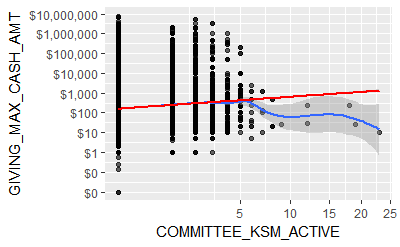

```r
scatterplotter('COMMITTEE_KSM_ACTIVE') +
  scale_x_sqrt()
```

Likely unhelpful since I don’t know committees the year largest gift was made. **EXCLUDE**

```r
summary2(full.data$COMMITTEE_KSM_YEARS %>% sqrt())
```

```
     Min.   1st Qu.    Median      Mean   3rd Qu.      Max.     StDev Skewnewss  Kurtosis
    0.000     0.000     0.000     0.398     1.000     3.610     0.668     1.430     0.957
```

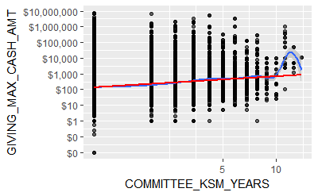

```r
scatterplotter('COMMITTEE_KSM_YEARS') +
  scale_x_sqrt()
```

Looks fine.

```r
summary2(full.data$COMMITTEE_KSM_LDR %>% sqrt())
```

```
     Min.   1st Qu.    Median      Mean   3rd Qu.      Max.     StDev Skewnewss  Kurtosis
   0.0000    0.0000    0.0000    0.0299    0.0000    2.4500    0.1920    6.6900   46.0000
```

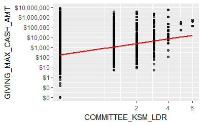

```r
scatterplotter('COMMITTEE_KSM_LDR') +
  scale_x_sqrt()
```

Looks ok but consider combining based on counts. **Consider additional transformation**

```r
summary2(full.data$COMMITTEE_KSM_LDR_ACTIVE %>% sqrt())
```

```
     Min.   1st Qu.    Median      Mean   3rd Qu.      Max.     StDev Skewnewss  Kurtosis
   0.0000    0.0000    0.0000    0.0126    0.0000    2.0000    0.1190    9.7300   96.6000
```

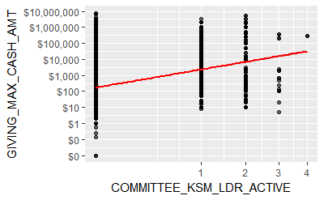

```r
scatterplotter('COMMITTEE_KSM_LDR_ACTIVE') +
  scale_x_sqrt()
```

Nonmonontonic relationship; does that make sense? Artifact? **EXCLUDE**

```r
summary2(full.data$KSM_EVENTS_ATTENDED %>% sqrt())
```

```
     Min.   1st Qu.    Median      Mean   3rd Qu.      Max.     StDev Skewnewss  Kurtosis
    0.000     0.000     0.000     0.400     1.000     7.870     0.775     2.210     6.010
```

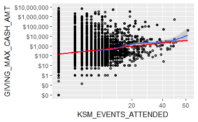

```r
scatterplotter('KSM_EVENTS_ATTENDED') +
  scale_x_sqrt()
```

Looks ok.

```r
summary2(full.data$KSM_EVENTS_YRS %>% sqrt())
```

```
     Min.   1st Qu.    Median      Mean   3rd Qu.      Max.     StDev Skewnewss  Kurtosis
    0.000     0.000     0.000     0.349     1.000     3.320     0.636     1.590     1.330
```

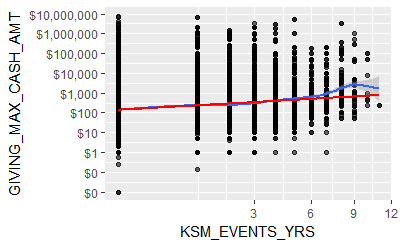

```r
scatterplotter('KSM_EVENTS_YRS') +
  scale_x_sqrt()
```

Looks ok.

```r
summary2(full.data$KSM_EVENTS_PREV_3_FY %>% sqrt())
```

```
     Min.   1st Qu.    Median      Mean   3rd Qu.      Max.     StDev Skewnewss  Kurtosis
    0.000     0.000     0.000     0.248     0.000     6.160     0.596     2.780     9.190
```

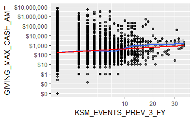

```r
scatterplotter('KSM_EVENTS_PREV_3_FY') +
  scale_x_sqrt()
```

Looks ok.

```r
summary2(full.data$KSM_EVENTS_REUNIONS %>% sqrt())
```

```
     Min.   1st Qu.    Median      Mean   3rd Qu.      Max.     StDev Skewnewss  Kurtosis
    0.000     0.000     0.000     0.165     0.000     2.450     0.416     2.300     3.840
```

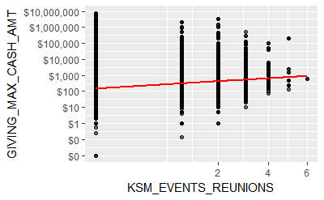

```r
scatterplotter('KSM_EVENTS_REUNIONS') +
  scale_x_sqrt()
```

Looks ok, but could also work as an indicator; how many people have really gone to 4+? **Consider additional transformation**

```r
summary2(full.data$KSM_SPEAKER_YEARS %>% sqrt())
```

```
     Min.   1st Qu.    Median      Mean   3rd Qu.      Max.     StDev Skewnewss  Kurtosis
 0.00e+00  0.00e+00  0.00e+00  4.31e-03  0.00e+00  1.41e+00  6.56e-02  1.52e+01  2.29e+02
```

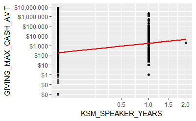

```r
scatterplotter('KSM_SPEAKER_YEARS') +
  scale_x_sqrt()
```

Just started tracking. Good candidate for binary indicator. **Consider additional transformation**

```r
summary2(full.data$KSM_SPEAKER_TIMES %>% sqrt())
```

```
     Min.   1st Qu.    Median      Mean   3rd Qu.      Max.     StDev Skewnewss  Kurtosis
 0.00e+00  0.00e+00  0.00e+00  6.35e-03  0.00e+00  2.83e+00  1.05e-01  1.92e+01  4.09e+02
```

```r
summary(full.data$KSM_SPEAKER_TIMES %>% factor())
```

```
    0     1     2     3     4     8
92826   232    23     3    99    44
```

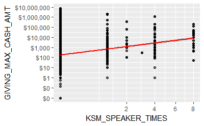

```r
scatterplotter('KSM_SPEAKER_TIMES') +
  scale_x_sqrt()
```

Good candidate for binary indicator, though that’s duplicative with the above. **Consider additional transformation**

```r
summary2(full.data$KSM_FEATURED_COMM_YEARS %>% sqrt())
```

```
     Min.   1st Qu.    Median      Mean   3rd Qu.      Max.     StDev Skewnewss  Kurtosis
 0.00e+00  0.00e+00  0.00e+00  3.07e-03  0.00e+00  1.73e+00  5.72e-02  1.90e+01  3.71e+02
```

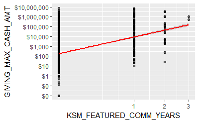

```r
scatterplotter('KSM_FEATURED_COMM_YEARS') +
  scale_x_sqrt()
```

Good candidate for binary indicator. **Consider additional transformation**

```r
summary2(full.data$KSM_FEATURED_COMM_TIMES %>% sqrt())
```

```
     Min.   1st Qu.    Median      Mean   3rd Qu.      Max.     StDev Skewnewss  Kurtosis
 0.00e+00  0.00e+00  0.00e+00  3.13e-03  0.00e+00  2.00e+00  5.89e-02  1.96e+01  4.04e+02
```

```r
summary(full.data$KSM_FEATURED_COMM_TIMES %>% factor())
```

```
    0     1     2     3     4
92955   232    32     4     4
```

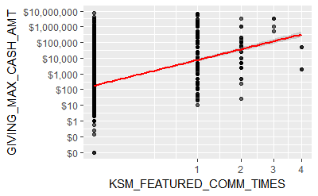

```r
scatterplotter('KSM_FEATURED_COMM_TIMES') +
  scale_x_sqrt()
```

Good candidate for binary indicator, though that’s duplicative with the above. **EXCLUDE**

```r
summary2(full.data$KSM_CORP_RECRUITER_YEARS %>% sqrt())
```

```
     Min.   1st Qu.    Median      Mean   3rd Qu.      Max.     StDev Skewnewss  Kurtosis
   0.0000    0.0000    0.0000    0.0047    0.0000    1.0000    0.0684   14.5000  208.0000
```

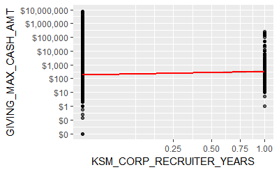

```r
scatterplotter('KSM_CORP_RECRUITER_YEARS') +
  scale_x_sqrt()
```

Looks fine; treat as binary indicator.

```r
summary2(full.data$KSM_CORP_RECRUITER_TIMES %>% sqrt())
```

```
     Min.   1st Qu.    Median      Mean   3rd Qu.      Max.     StDev Skewnewss  Kurtosis
   0.0000    0.0000    0.0000    0.0047    0.0000    1.0000    0.0684   14.5000  208.0000
```

```r
summary(full.data$KSM_CORP_RECRUITER_TIMES %>% factor())
```

```
    0     1
92789   438
```

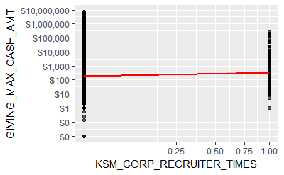

```r
scatterplotter('KSM_CORP_RECRUITER_TIMES') +
  scale_x_sqrt()
```

Duplicative with above. **EXCLUDE**

```r
summary2(full.data$ATHLETICS_TICKET_YEARS %>% sqrt())
```

```
     Min.   1st Qu.    Median      Mean   3rd Qu.      Max.     StDev Skewnewss  Kurtosis
   0.0000    0.0000    0.0000    0.0492    0.0000    3.3200    0.3430    7.6500   60.5000
```

```r
summary(full.data$ATHLETICS_TICKET_YEARS %>% factor())
```

```
    0     1     2     3     4     5     6     7     8     9    10    11
91018   594   266   155   174   107   128    58    68    58   448   153
```

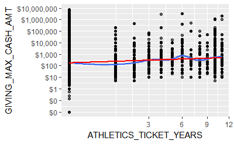

```r
scatterplotter('ATHLETICS_TICKET_YEARS') +
  scale_x_sqrt()
```

Looks fine.

```r
summary2(full.data %>% filter(ATHLETICS_TICKET_LAST > 0) %>% select(ATHLETICS_TICKET_LAST) %>%
           unlist())
```

```
     Min.   1st Qu.    Median      Mean   3rd Qu.      Max.     StDev Skewnewss  Kurtosis
 2010.000  2010.000  2020.000  2010.000  2020.000  2020.000     3.140    -1.340     0.687
```

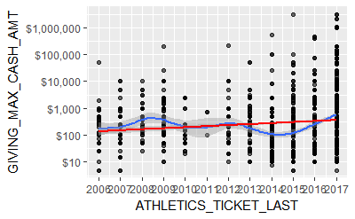

```r
scatterplotter('ATHLETICS_TICKET_LAST'
               , data = full.data %>% filter(ATHLETICS_TICKET_LAST > 0)) +
  scale_x_continuous(breaks = 2000:2050)
```

Looks fine.

## Additional exploration

### Count of cash gifts

```r
full.data %>% filter(GIFTS_CASH > 0) %>% select(GIFTS_CASH) %>%
  mutate(GIFTS_CASH = cut(GIFTS_CASH, 50)) %>% summary()
```

```
       GIFTS_CASH
 (0.695,7.1]:27148
 (7.1,13.2] : 3982
 (13.2,19.3]: 1945
 (19.3,25.4]: 1142
 (25.4,31.5]:  675
 (31.5,37.6]:  350
 (Other)    :  203
```

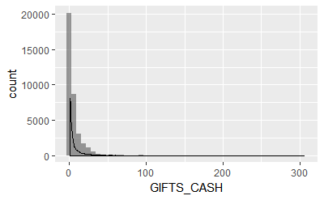

```r
histogrammer('GIFTS_CASH', data = full.data %>% filter(GIFTS_CASH > 0), m = 50)
```

Looks like around 95% of the donors have given no more than 25 cash gifts.

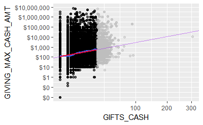

```r
# Full dataset regression line for comparison
lmtmp <- full.data %>% filter(GIVING_MAX_CASH_AMT > 0) %>%
  lm(log10(GIVING_MAX_CASH_AMT) ~ sqrt(GIFTS_CASH), data = .)
# Plot
scatterplotter('GIFTS_CASH', data = full.data %>% filter(GIFTS_CASH < 25)) +
  # Filtered data
  geom_point(aes(x = GIFTS_CASH, y = GIVING_MAX_CASH_AMT),
             data = full.data %>% filter(GIFTS_CASH >= 25),
             color = 'gray', alpha = .5) +
  scale_x_sqrt() +
  geom_abline(slope = lmtmp$coefficients[2], intercept = lmtmp$coefficients[1],
              linetype = 'solid', color = 'purple', alpha = .5)
```

```r
remove(lmtmp)
```

The red line is a linear regression for $x < 25$ (excluding gray points) while the purple line is for the full dataset. Turns out that the (relatively) extreme values really make no difference.

### Count of credit card gifts

```r
full.data %>% filter(GIFTS_CREDIT_CARD > 0) %>% select(GIFTS_CREDIT_CARD) %>%
  mutate(GIFTS_CREDIT_CARD = cut(GIFTS_CREDIT_CARD, 25)) %>% summary()
```

```
   GIFTS_CREDIT_CARD
 (0.935,3.6]:17310
 (3.6,6.2]  : 3899
 (6.2,8.8]  : 1133
 (8.8,11.4] :  931
 (11.4,14]  :  546
 (14,16.6]  :  229
 (Other)    :  477
```

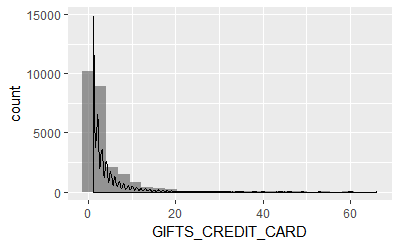

```r
histogrammer('GIFTS_CREDIT_CARD', data = full.data %>% filter(GIFTS_CREDIT_CARD > 0), m = 25)
```

```r
quantile(full.data %>% filter(GIFTS_CREDIT_CARD > 0) %>% select(GIFTS_CREDIT_CARD) %>% unlist, .9)
```

```
90%
  8
```

90th quantile is at $x = 8$.

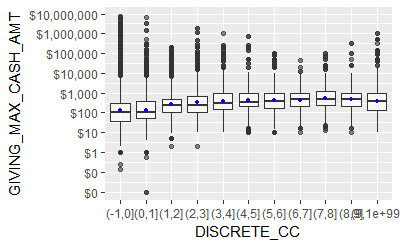

```r
full.data %>% filter(GIVING_MAX_CASH_AMT > 0) %>%
  mutate(
    DISCRETE_CC = cut(GIFTS_CREDIT_CARD, breaks = c(-1:9, 1E99))
  ) %>%
boxplotter('DISCRETE_CC', data = .) +
  stat_summary(fun.y = mean, geom = 'point', size = 1, color = 'blue')
```

Honestly seems like **discretizing into 0, 1, and 2+ would work fine.** I suspect that the dip for very high CC gift count entities is due to recurring (monthly) transactions.

### Binary candidates

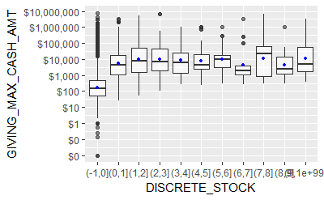

```r
full.data %>% mutate(DISCRETE_STOCK = cut(GIFTS_STOCK, c(-1:9, 1E99))) %>%
boxplotter('DISCRETE_STOCK', data = .) +
  stat_summary(fun.y = mean, geom = 'point', size = 1, color = 'blue')
```

**Treat `GIFTS_STOCK` as binary.**

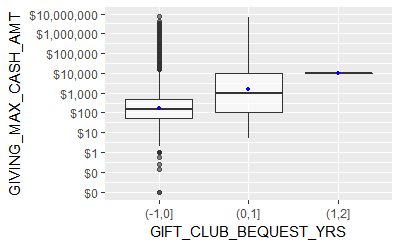

```r
full.data %>% mutate(GIFT_CLUB_BEQUEST_YRS = cut(GIFT_CLUB_BEQUEST_YRS, c(-1:2))) %>%
boxplotter('GIFT_CLUB_BEQUEST_YRS', data = .) +
  stat_summary(fun.y = mean, geom = 'point', size = 1, color = 'blue')
```

**Treat `GIFT_CLUB_BEQUEST_YRS` as binary.**

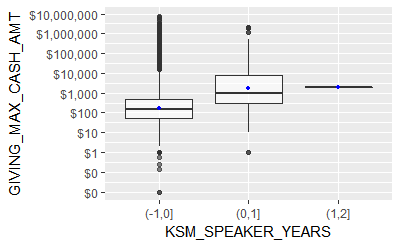

```r
full.data %>% mutate(KSM_SPEAKER_YEARS = cut(KSM_SPEAKER_YEARS, c(-1:2, 1E99))) %>%
boxplotter('KSM_SPEAKER_YEARS', data = .) +
  stat_summary(fun.y = mean, geom = 'point', size = 1, color = 'blue')
```

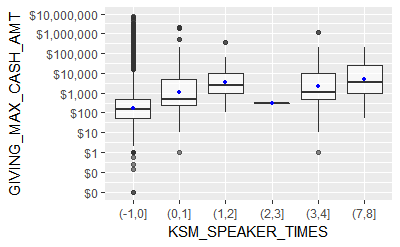

```r
full.data %>% mutate(KSM_SPEAKER_TIMES = cut(KSM_SPEAKER_TIMES, c(-1:8, 1E99))) %>%
boxplotter('KSM_SPEAKER_TIMES', data = .) +
  stat_summary(fun.y = mean, geom = 'point', size = 1, color = 'blue')
```

**Use binary indicator on `KSM_SPEAKER_YEARS` and exclude `KSM_SPEAKER_TIMES`.**

### KSM leadership committees

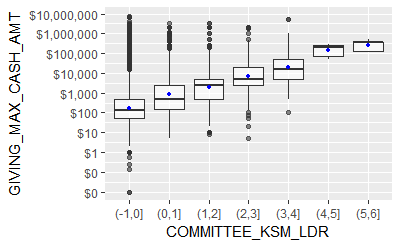

```r
full.data %>% mutate(COMMITTEE_KSM_LDR = cut(COMMITTEE_KSM_LDR, c(-1:6, 1E99))) %>%
boxplotter('COMMITTEE_KSM_LDR', data = .) +
  stat_summary(fun.y = mean, geom = 'point', size = 1, color = 'blue')
```

Seems fine to leave as is.

### KSM Reunion attendance

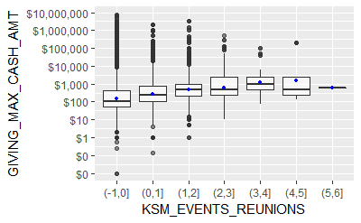

```r
full.data %>% mutate(KSM_EVENTS_REUNIONS = cut(KSM_EVENTS_REUNIONS, c(-1:6, 1E99))) %>%
boxplotter('KSM_EVENTS_REUNIONS', data = .) +
  stat_summary(fun.y = mean, geom = 'point', size = 1, color = 'blue')
```

**Split `KSM_EVENTS_REUNIONS` into 0, 1, 2, 3+.**

### Featured communication years count

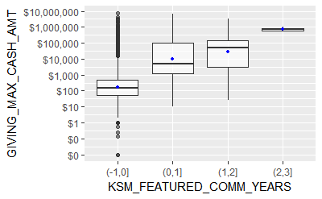

```r
full.data %>% mutate(KSM_FEATURED_COMM_YEARS = cut(KSM_FEATURED_COMM_YEARS, c(-1:3, 1E99))) %>%
boxplotter('KSM_FEATURED_COMM_YEARS', data = .) +
  stat_summary(fun.y = mean, geom = 'point', size = 1, color = 'blue')
```

This is somewhat problematic because people are often featured because they gave. Might as well try it though. **Treat `KSM_FEATURED_COMM_YEARS` as binary.**

### Loyal gift club

```r
full.data %>% mutate(GIFT_CLUB_LOYAL_YRS = cut(GIFT_CLUB_LOYAL_YRS, c(-1:6, 1E99))) %>%
  select(GIFT_CLUB_LOYAL_YRS) %>% summary()
```

```
 GIFT_CLUB_LOYAL_YRS
 (-1,0] :79584
 (0,1]  : 4327
 (4,5]  : 2440
 (1,2]  : 2363
 (5,6]  : 1720
 (2,3]  : 1627
 (Other): 1166
```

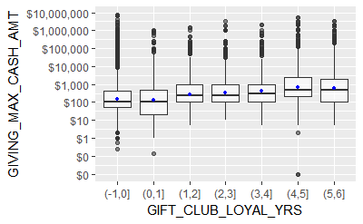

```r
full.data %>% mutate(GIFT_CLUB_LOYAL_YRS = cut(GIFT_CLUB_LOYAL_YRS, c(-1:6, 1E99))) %>%
boxplotter('GIFT_CLUB_LOYAL_YRS', data = .) +
  stat_summary(fun.y = mean, geom = 'point', size = 1, color = 'blue')
```

Looks fine as-is; good proportion within each bin.

### Non-KSM NU leadership gift clubs

```r
full.data %>% mutate(GIFT_CLUB_NU_LDR_YRS = cut(GIFT_CLUB_NU_LDR_YRS, c(-1:16, 1E99))) %>%
  select(GIFT_CLUB_NU_LDR_YRS) %>% table()
```

```
.
    (-1,0]      (0,1]      (1,2]      (2,3]      (3,4]      (4,5]      (5,6]      (6,7]
     82467       3287       1540       1582        748        620        456        402
     (7,8]      (8,9]     (9,10]    (10,11]    (11,12]    (12,13]    (13,14]    (14,15]
       348        297        315        308        370        249         96         91
   (15,16] (16,1e+99]
        51          0
```

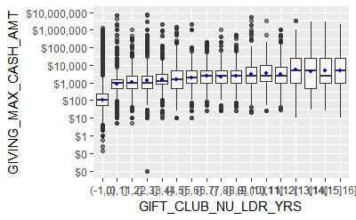

```r
full.data %>% mutate(GIFT_CLUB_NU_LDR_YRS = cut(GIFT_CLUB_NU_LDR_YRS, c(-1:16, 1E99))) %>%
boxplotter('GIFT_CLUB_NU_LDR_YRS', data = .) +
  stat_summary(fun.y = mean, geom = 'point', size = 1, color = 'blue')
```

## Derived features

### Visits

Does total visits (in the last 5 FY) make sense as a sqrt or log10 variable?

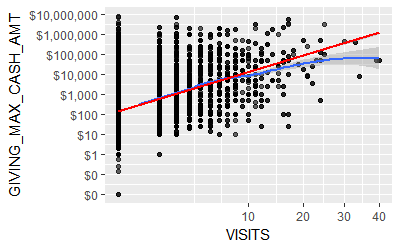

```r
scatterplotter('VISITS') + scale_x_sqrt()
```

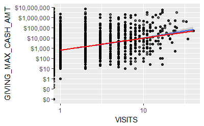

```r
scatterplotter('VISITS') + scale_x_log10()
```

Much more convincing on a log-10 scale. **Use summed `VISITS` on a log-10 scale.**

### X out of 5 loyalty

Does `GIVING_MAX_CASH_AMT` vary with number of years giving in last 5?

Let $FY_t$ denote fiscal year cash giving in year $t$. If $\mathbf{1}$ is the indicator function:

$$P_5 = \frac{1}{5} \left[ \sum_{i=0}^{4} \mathbf{1}\left\{ FY_{t-i} > 0 \right\} \right]$$

```r
full.data %>% mutate(
  LAST_5_PCT = 1/5 * (
    ifelse(CASH_PFY1 > 0, 1, 0)
    + ifelse(CASH_PFY2 > 0, 1, 0)
    + ifelse(CASH_PFY3 > 0, 1, 0)
    + ifelse(CASH_PFY4 > 0, 1, 0)
    + ifelse(CASH_PFY5 > 0, 1, 0)
  )
) %>% select(LAST_5_PCT) %>% table()
```

```
.
    0   0.2   0.4   0.6   0.8     1
73991  8386  3494  2289  2075  2992
```

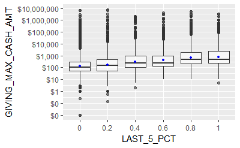

```r
full.data %>% mutate(
  LAST_5_PCT = {1/5 * (
    ifelse(CASH_PFY1 > 0, 1, 0)
    + ifelse(CASH_PFY2 > 0, 1, 0)
    + ifelse(CASH_PFY3 > 0, 1, 0)
    + ifelse(CASH_PFY4 > 0, 1, 0)
    + ifelse(CASH_PFY5 > 0, 1, 0)
  )} %>% factor()
) %>% boxplotter('LAST_5_PCT', data = .) +
  stat_summary(fun.y = mean, geom = 'point', size = 1, color = 'blue')
```

Very nice linear trend. **Include `LAST_5_PCT` as a variable.**

### Upgrade behavior

Does `GIVING_MAX_CASH_AMT` vary as a function of upgrades/downgrades?

$$U_5 = \sum_{i=0}^{4} \text{sign}\left( FY_{t-i} - FY_{t-i-1} \right)$$

```r
full.data %>% mutate(
  UPGRADE5 =
      sign(CASH_PFY1 - CASH_PFY2)
    + sign(CASH_PFY2 - CASH_PFY3)
    + sign(CASH_PFY3 - CASH_PFY4)
    + sign(CASH_PFY4 - CASH_PFY5)
) %>% select(UPGRADE5) %>% table()
```

```
.
   -4    -3    -2    -1     0     1     2     3     4
    4    23   502  4743 82165  4387  1155   188    60
```

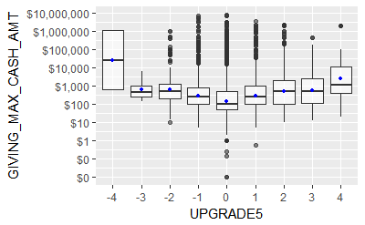

```r
full.data %>% mutate(
  UPGRADE5 = factor(
      sign(CASH_PFY1 - CASH_PFY2)
    + sign(CASH_PFY2 - CASH_PFY3)
    + sign(CASH_PFY3 - CASH_PFY4)
    + sign(CASH_PFY4 - CASH_PFY5)
  )
) %>% boxplotter('UPGRADE5', data = .) +
  stat_summary(fun.y = mean, geom = 'point', size = 1, color = 'blue')
```

Clearly nonlinear. Based on the counts, probably treat this as -2 to +2.

Try 3 years:

```r
full.data %>% mutate(
  UPGRADE3 =
      sign(CASH_PFY1 - CASH_PFY2)
    + sign(CASH_PFY2 - CASH_PFY3)
) %>% select(UPGRADE3) %>% table()
```

```
.
   -2    -1     0     1     2
  407  3294 84900  3726   900
```

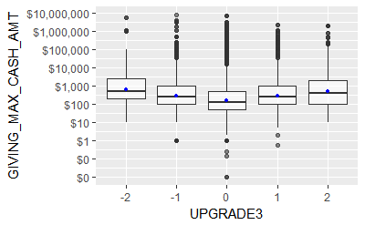

```r
full.data %>% mutate(
  UPGRADE3 = factor(
      sign(CASH_PFY1 - CASH_PFY2)
    + sign(CASH_PFY2 - CASH_PFY3)
  )
) %>% boxplotter('UPGRADE3', data = .) +
  stat_summary(fun.y = mean, geom = 'point', size = 1, color = 'blue')
```

This is rather counterintuitive: people who have downgraded are more likely to have given a large gift compared to constant donors? Is this a Reunion effect? **Include `UPGRADE3` giving behaviors.**